# Life/Death population

Part of my CLT stress test. A made-up age-at-death distribution with two humps.

Author

Geonho Lee

Published

October 11, 2026

```r
source("clt_helpers.R")

student_id <- 5146
cutoff <- 0.3
```

## 1 The population

This is the age-at-death distribution from the class handout. Ages go from 0 to 100. There is a spike of deaths at age 0 that drops off fast, and then a second, bell-shaped hump centered at 65. The handout says it was built to copy the shape of a graph, so it is not real mortality data. I built it the same way the handout does. The draws are independent, all from the same distribution, and since age is stuck between 0 and 100 the variance is finite, so all three CLT assumptions hold.

```r
# same construction as the class handout
age <- 0:100
early_component <- 0.045 * exp(-age / 5)
adult_component <- 0.030 * exp(-0.5 * ((age - 65) / 10)^2)
weight <- early_component + adult_component
probability <- weight / sum(weight)

rdeath <- function(n) {
  sample(x = age, size = n, replace = TRUE, prob = probability)
}

pop_mean <- sum(age * probability)
pop_sd <- sqrt(sum((age - pop_mean)^2 * probability))
pop_skew <- sum((age - pop_mean)^3 * probability) / pop_sd^3
pop_exkurt <- sum((age - pop_mean)^4 * probability) / pop_sd^4 - 3

round(c(pop_mean = pop_mean, pop_sd = pop_sd, pop_skew = pop_skew, pop_kurtosis = pop_exkurt + 3), 3)
```

```
    pop_mean       pop_sd     pop_skew pop_kurtosis
      49.981       27.635       -0.862        2.210
```

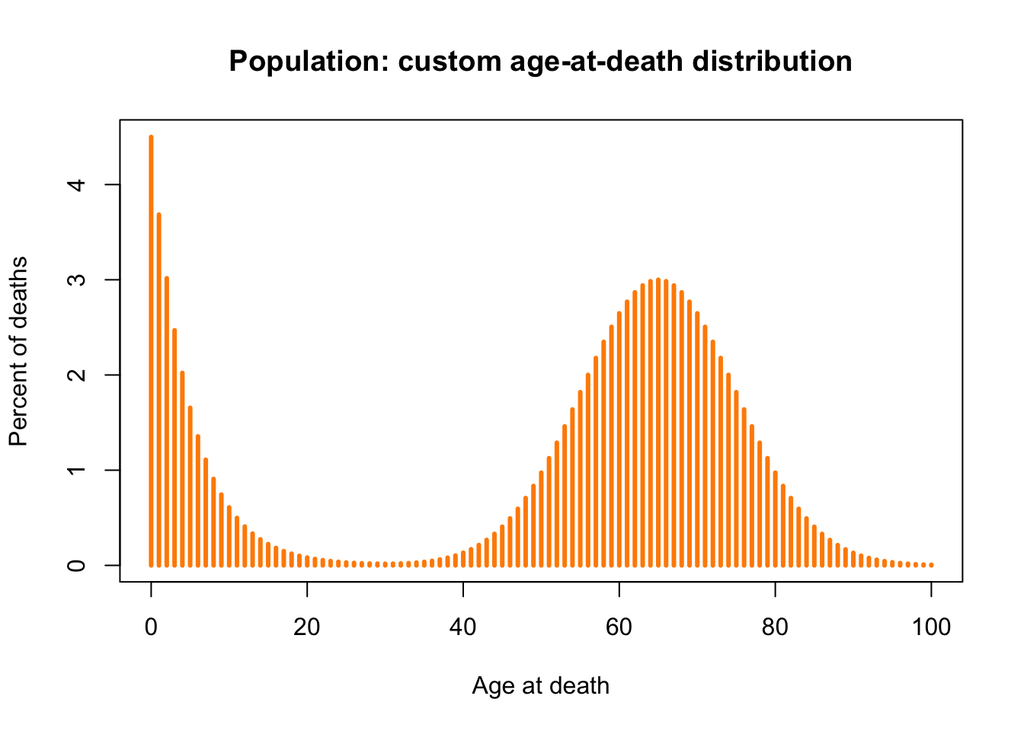

Probability of each age at death.

```r
plot(age, 100 * probability, type = "h", lwd = 3, col = "darkorange",
     xlab = "Age at death", ylab = "Percent of deaths",
     main = "Population: custom age-at-death distribution")
```

The mean is 49.98 and the sd is 27.63, the same as in the handout. The skewness is -0.86, so it leans left (the early deaths pull the mean down), and the kurtosis is 2.21, so its tails are lighter than a normal. One odd thing is that the mean, about 50, is not a very common age to die here. Age 50 has about 1% of deaths while age 65 has about 3%.

## 2 What I expected before running anything

Same formulas as the other files. Skewness needs n of about 8.3 to get within 0.3 of zero, and kurtosis only needs about 2.6. So I predicted n = 9. The population looks strange, but its skewness (-0.86) is smaller in size than the binomial’s (1.19) or the exponential’s (2), so I expected it to be one of the faster ones.

```r
n_for_skew <- (pop_skew / cutoff)^2
n_for_kurt <- abs(pop_exkurt) / cutoff

c(n_for_skew = n_for_skew, n_for_kurt = n_for_kurt)
```

```
n_for_skew n_for_kurt
  8.259327   2.633616
```

## 3 Simulation

For each n I draw 10,000 samples of n deaths and keep the mean age of each sample. Same 51 values of n as the exponential file.

```r
sim <- run_simulation(
  generator = rdeath,
  pop_sd = pop_sd,
  seed = student_id
)

results <- sim$results
```

## 4 What happens as n grows

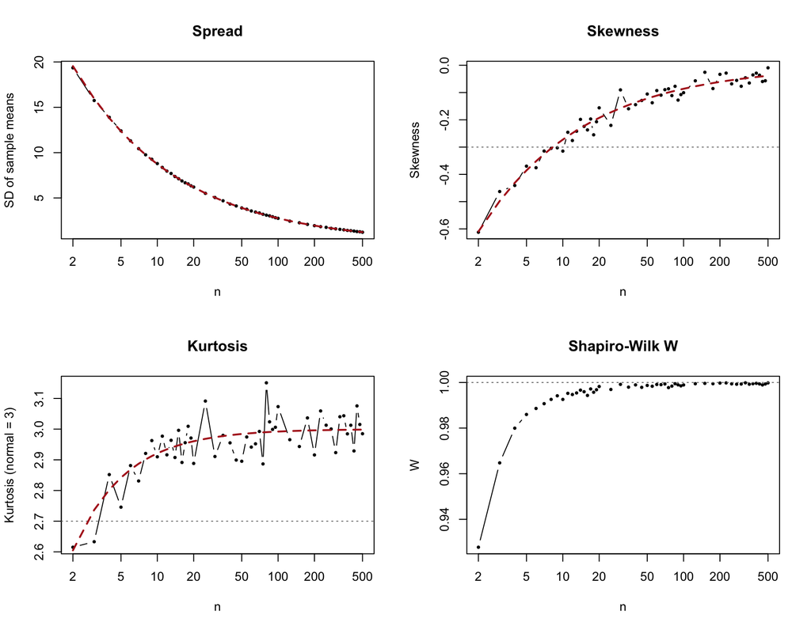

Red dashed = theory, gray dotted = my cutoff.

```r
plot_trends(results, pop_skew = pop_skew, pop_exkurt = pop_exkurt, cutoff = cutoff)
```

```r
show_rows <- results$n %in% c(2, 3, 5, 8, 9, 10, 11, 12, 20, 30, 50, 100, 500)
knitr::kable(round(results[show_rows, ], 3), row.names = FALSE)
```

| n | mean | sd | theory_se | skewness | kurtosis | shapiro_w | sd_error |
| --- | --- | --- | --- | --- | --- | --- | --- |
| 2 | 50.313 | 19.353 | 19.541 | -0.612 | 2.615 | 0.928 | 0.010 |
| 3 | 50.248 | 15.751 | 15.955 | -0.463 | 2.633 | 0.965 | 0.013 |
| 5 | 49.797 | 12.406 | 12.359 | -0.370 | 2.746 | 0.986 | 0.004 |
| 8 | 50.115 | 9.763 | 9.770 | -0.305 | 2.921 | 0.993 | 0.001 |
| 9 | 50.004 | 9.272 | 9.212 | -0.303 | 2.963 | 0.994 | 0.007 |
| 10 | 50.005 | 8.795 | 8.739 | -0.315 | 2.910 | 0.993 | 0.006 |
| 11 | 49.946 | 8.370 | 8.332 | -0.246 | 2.977 | 0.995 | 0.005 |
| 12 | 49.861 | 7.966 | 7.977 | -0.276 | 2.916 | 0.995 | 0.001 |
| 20 | 49.945 | 6.207 | 6.179 | -0.156 | 2.888 | 0.998 | 0.004 |
| 30 | 50.000 | 5.054 | 5.045 | -0.090 | 2.911 | 0.999 | 0.002 |
| 50 | 50.022 | 3.902 | 3.908 | -0.105 | 2.895 | 0.999 | 0.002 |
| 100 | 49.964 | 2.754 | 2.763 | -0.101 | 3.073 | 0.999 | 0.003 |
| 500 | 49.989 | 1.223 | 1.236 | -0.009 | 2.985 | 1.000 | 0.011 |

```r
# checks over every n I tried, not just the rows above
c(max_mean_gap = round(max(abs(results$mean - pop_mean)), 3),
  max_sd_error = round(max(results$sd_error), 3))
```

```
max_mean_gap max_sd_error
       0.332        0.014
```

The mean is always within about 0.33 years of 49.98, and the sd always stays within 1.4% of σ/√n. Kurtosis only fails at n = 2 and 3 (2.62 and 2.63). Skewness is what holds it back. It starts at -0.61 at n = 2, follows the red theory line up toward 0, and stays outside my cutoff through n = 10. Shapiro W goes from 0.928 at n = 2 to 0.999 at n = 30.

## 5 A closer look

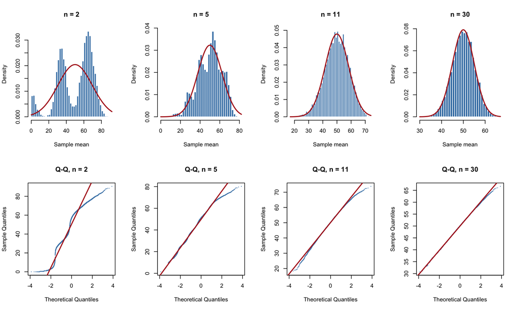

```r
chosen_n <- smallest_n(results, cutoff = cutoff)
plot_means(sim, show_n = c(2, 5, chosen_n, 30), pop_mean = pop_mean, pop_sd = pop_sd)
```

The n = 2 histogram has three bumps instead of two. I think it is because two random deaths can be both young, one young and one old, or both old, and each of those lands in a different place:

```r
# share of the n = 2 means near each bump
m2 <- sim$means[["2"]]
c(under_15 = mean(m2 < 15), from_15_to_50 = mean(m2 >= 15 & m2 < 50), over_50 = mean(m2 >= 50))
```

```
     under_15 from_15_to_50       over_50
       0.0565        0.3803        0.5632
```

```r
# rough guess, calling anyone who dies before 20 "young"
p_young <- sum(probability[age < 20])
c(both_young = p_young^2, one_each = 2 * p_young * (1 - p_young), both_old = (1 - p_young)^2)
```

```
both_young   one_each   both_old
 0.0593808  0.3686019  0.5720173
```

The guess gives about 6%, 37% and 57%, and the simulation gives about 6%, 38% and 56%. My cut points are rough, so they do not line up perfectly, but the three bumps are those three cases.

At n = 5 the empty stretch between the first two bumps (around ages 11 to 21 at n = 2) is gone, but the histogram is still lumpy, the Q-Q plot still wiggles in the middle, and the top end bends well under the line. At n = 11 the histogram is a smooth bell. The Q-Q plot is straight through the middle and both ends dip a little under the line, which is what a slight left skew looks like. By n = 30 the points sit on the line except for the very top.

## 6 My decision

```r
chosen_n
```

```
[1] 11
```

Same rule as the other files: skewness and kurtosis within 0.3 of normal, sd within 3% of theory, and it has to keep passing for every bigger n. The smallest n that passes is **n = 11**. That is 2 more than I predicted, so I looked at skewness around the cutoff:

```r
around <- results[results$n %in% 7:13, c("n", "skewness")]
around$formula <- pop_skew / sqrt(around$n)
print(round(around, 3), row.names = FALSE)
```

```
  n skewness formula
  7   -0.314  -0.326
  8   -0.305  -0.305
  9   -0.303  -0.287
 10   -0.315  -0.273
 11   -0.246  -0.260
 12   -0.276  -0.249
 13   -0.242  -0.239
```

The formula crosses -0.3 between n = 8 and 9. My simulation sits right on the edge there (-0.305 at n = 8 and -0.303 at n = 9), then n = 10 comes out at -0.315, so the first n that passes and keeps passing is 11.

Same data, different cutoff:

```r
data.frame(
  cutoff = c(0.5, 0.3, 0.2, 0.1, 0.05),
  smallest_n = sapply(c(0.5, 0.3, 0.2, 0.1, 0.05), function(k) smallest_n(results, cutoff = k))
)
```

```
  cutoff smallest_n
1   0.50          3
2   0.30         11
3   0.20         30
4   0.10        125
5   0.05        500
```

With a 0.5 cutoff, n = 3 is enough, and even with a strict 0.2 cutoff the answer is exactly 30. So for this population, 30 works under any of the cutoffs I would actually use. Like in the other files, I do not put much weight on the 0.1 and 0.05 rows because of simulation noise.

## 7 Does the seed matter?

```r
sim_167 <- run_simulation(
  generator = rdeath,
  pop_sd = pop_sd,
  seed = 167
)
smallest_n(sim_167$results, cutoff = cutoff)
```

```
[1] 11
```

Seed 167 also gives n = 11, so both seeds agree.

## 8 What surprised me

The formula said this one would be fast, and it was. It still looked wrong while it was happening. The population with a spike at 0 and a hump at 65 is the strangest-looking one in the project, and it beat the binomial, which looks a lot tamer. The reason is that its skewness is only -0.86. How strange the shape looks does not matter much on its own. The other surprise was the three bumps at n = 2. Averages usually just get squeezed toward the middle, but with two people you can actually see the three combinations (both young, one of each, both old) before it all blends together.